# **Lab**

[figure not shown]

### **What?**

Since my knowledge of data science has been growing, I’ve been coming up with new ways to satisfy my curiosities and intuitions

For example, the most important words that you can find in Dante’s Divine Comedy, or how many times a newborn baby’s been fed in her first months of life.

This lab was born to show some examples of how curiosity and data science, can trasform information into knowledge

Enjoy and have fun!

#### **Margherita’s breastfeeding**

My wife kept note every time she fed our little daughter (born the 2nd of september 2019). And I thought: Texts are data, and data means information, information needs dashboard. So I stole her notes to create a dashboard.

In some days there were a lack of data because of errors of data entry… I should consider firing her…

What can you learn from that?

p.s. when I showed that work to my wife, she stopped taking notes… -.-

Here’s **[Margherita’s breastfeeding](http://matteolocatelli.com/lab/html_breastfeeding.html)**

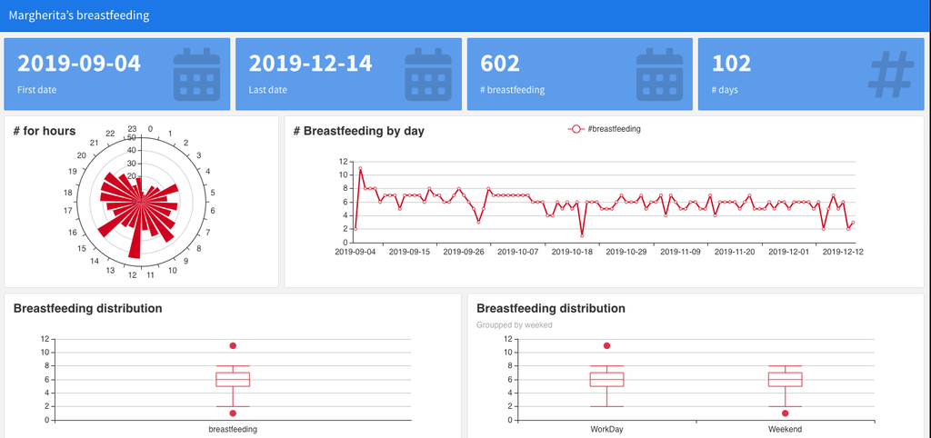

#### **Hackathon Topic Modeling**

In June 2019 I attended to a hackathon with 4 friends of mine. The hackathon was on documents modeling and in particular composed of 3 tasks: - Assign every document (totally ~700) to a topic, based on 6 topics available - Create a unsupervised model to create links between documents - Design and build a UI to explore and use analysis

The documents were given at 8a.m. and the delivery was at 7p.m. so we didn’t have much time.

In the previous weeks we prepared ourselves as best as we could. We prepared beforehand many scripts and Spark environments just in case of ther would be *Big Data*. We discovered the amazing TiKa from Apache which was used to parse data and it changed everything!

Then thanks to LDA we assign topic to each documents and with cosine similarities we create the network.

The main attraction was a bot on telegram that applied classification model to a text written by users. You can see it clicking the image below.

[figure not shown]

Last but not least, with R (RMarkdown) we created an HTML and you can see it in the link below.

Here’s the UI that we used to show the analysis As you can see, it was done in 30 minutes. Every time I see it I ask myself if I should modify it and make it seem more *professional*. But we won with that dashboard so I prefer to keep it as is

**[Hackathon Dashboard](http://matteolocatelli.com/lab/html_hackathon.html)**

**[LinkedIn Post](https://www.linkedin.com/posts/matteo-locatelli-25936639_tika-hackathon-wmf-activity-6549692309401858049-dteh)**

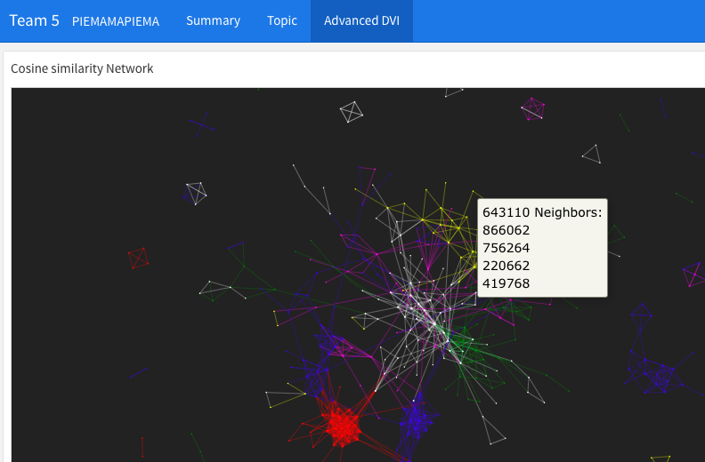

#### **Audio file to text**

During COVID-19 quarantine, I heard my wife speaking with her collegues about a lesson recorded and then she had to transcript it. The lesson took 2 hours so I decided to try to convert that audio in text helping her and hers collegues.

I’ve never try Google Speech APIs and I didn’t know about the limit of 15 minutes. So I built a python loop that splits audio in blocks of 200 seconds and then gather all the pieces.

Here’s **[Audio to Text](http://51.91.253.116:3838/audio2text/)**

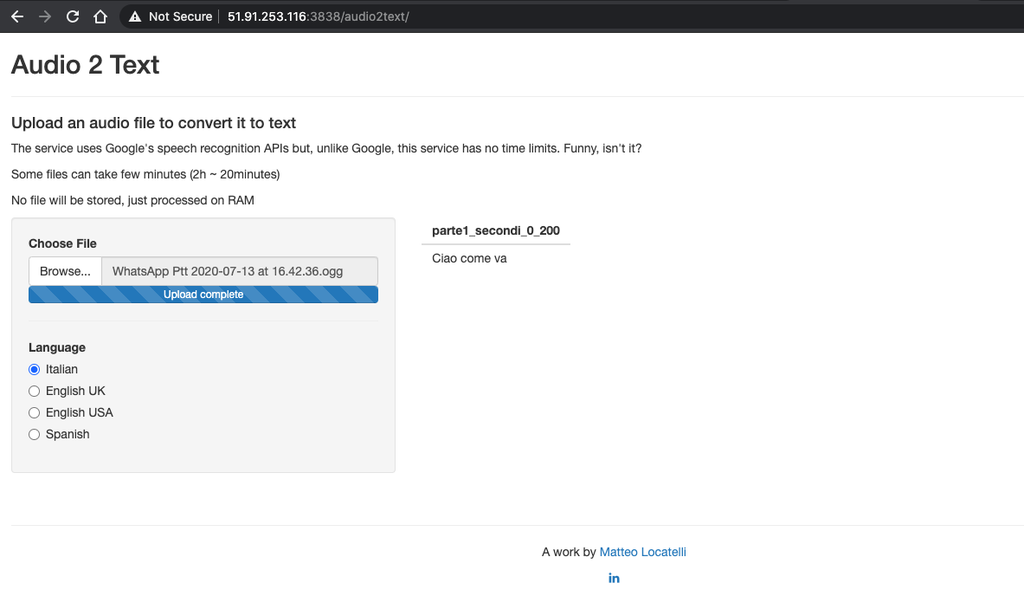

A work by [Matteo Locatelli](http://matteolocatelli.com/)